# Homework 1 (Hard deadline: 18.10.2026 22:00:)

- Use file Activities2018-2025.csv
- Read it first in Pandas DataFrame and then complete the tasks.
- Remember to comment your code, good policy is to have at least a short comment in every code cell.
- Add code cells when necessary.
- Good policy is to do one or few related operations in one code cell (e.g. read csv and check how it looks like in one cell and then e.g. df.info() in another etc.).

### Use of AI: can be used, but must be reported.

### AI shall not be used to complete the whole assignment.

```python
# Take necessary libraries in use
import pandas as pd
import matplotlib.pyplot as plt
import seaborn as sns
```

## Task 1: Data reading and checking (1 point)

- Read data (Activities2018-2025.csv) to a Pandas DataFrame whose name is df.
- Check that data looks ok.
- Show number of rows and columns.
- Show key data measures (mean, std, median, ...) for the DataFrame.
- Show also info about DataFrame.
- Check if there are missing values.

```python
# Read data (Activities2018-2025.csv) to a Pandas DataFrame whose name is df.
df = pd.read_csv("Activities2018-2025.csv")
# Set display options to show all columns
pd.set_option("display.max_columns", None)
df.head(10)
```

|  | Activity Type | Date | Favorite | Title | Distance | Calories | Time | Avg HR | Max HR | Aerobic TE | Avg Cadence | Max Cadence | Avg Pace | Best Pace | Total Ascent | Total Descent | Avg Stride Length | Avg Cadence.1 | Max Cadence.1 | Training Stress Score® | Total Strokes | Avg. Swolf | Avg Stroke Rate | Steps | Min Temp | Decompression | Best Lap Time | Number of Laps | Max Temp | … |
| --- | --- | --- | --- | --- | --- | --- | --- | --- | --- | --- | --- | --- | --- | --- | --- | --- | --- | --- | --- | --- | --- | --- | --- | --- | --- | --- | --- | --- | --- | --- |
| 0 | Walking | 2025-09-11 18:31:24 | False | Rusko Walking | 3,92 | 244 | 01:00:06 | 93 | 128 | 1,4 | 83 | 246 | 15:21 | 3:07 | 72 | 74 | 0,78 | -- | -- | 0,0 | -- | -- | -- | 5.574 | 23,0 | No | 01:00:06 | 1 | 27,0 | … |
| 1 | Cycling | 2025-09-10 18:49:40 | False | Rusko Cycling | 10,60 | 254 | 00:42:59 | 111 | 142 | 2,0 | -- | -- | 14,8 | 28,5 | 46 | 38 | -- | -- | -- | 0,0 | -- | -- | -- | -- | 20,0 | No | 00:19:25 | 2 | 28,0 | … |
| 2 | Other | 2025-09-08 15:47:11 | False | Salibandy | 0,00 | 580 | 01:28:15 | 117 | 169 | 3,1 | -- | -- | -- | -- | -- | -- | -- | -- | -- | 0,0 | -- | -- | -- | -- | 27,0 | No | 01:28:15 | 1 | 32,0 | … |
| 3 | Walking | 2025-09-08 07:25:35 | False | Rusko Walking | 3,48 | 373 | 00:41:03 | 133 | 183 | 3,8 | 109 | 243 | 11:47 | 7:02 | 58 | 65 | 0,78 | -- | -- | 0,0 | -- | -- | -- | 4.480 | 21,0 | No | 00:41:03 | 1 | 29,0 | … |
| 4 | Cycling | 2025-09-06 11:45:12 | False | Rusko Cycling | 21,08 | 331 | 01:07:16 | 104 | 141 | 2,0 | -- | -- | 18,8 | 34,1 | 212 | 89 | -- | -- | -- | 0,0 | -- | -- | -- | -- | 25,0 | No | 00:18:54 | 3 | 30,0 | … |
| 5 | Other | 2025-09-01 15:47:59 | False | Salibandy | 0,00 | 543 | 01:16:08 | 120 | 178 | 3,2 | -- | -- | -- | -- | -- | -- | -- | -- | -- | 0,0 | -- | -- | -- | -- | 27,0 | No | 01:16:08 | 1 | 31,0 | … |
| 6 | Hiking | 2025-08-30 16:51:54 | False | Pöytyä Hiking | 8,43 | 470 | 01:56:29 | 96 | 136 | 1,7 | 91 | 120 | 13:49 | 7:44 | 62 | 71 | 0,81 | -- | -- | 0,0 | -- | -- | -- | 10.828 | 20,0 | No | 00:09:22,0 | 2 | 25,0 | … |
| 7 | Hiking | 2025-08-30 13:04:13 | False | Pöytyä Hiking | 9,96 | 638 | 02:59:10 | 90 | 152 | 2,0 | 68 | 213 | 17:59 | 9:24 | 58 | 80 | 0,82 | -- | -- | 0,0 | -- | -- | -- | 13.970 | 22,0 | No | 00:40:59 | 2 | 28,0 | … |
| 8 | Walking | 2025-08-27 07:09:41 | False | Rusko Walking | 3,45 | 141 | 00:38:43 | 87 | 132 | 1,2 | 113 | 246 | 11:13 | 6:55 | 60 | 67 | 0,79 | -- | -- | 0,0 | -- | -- | -- | 4.440 | 20,0 | No | 00:38:43 | 1 | 28,0 | … |
| 9 | Walking | 2025-08-24 18:12:23 | False | Rusko Walking | 2,46 | 184 | 00:33:52 | 104 | 144 | 1,7 | 90 | 120 | 13:46 | 9:45 | 255 | 37 | 0,80 | -- | -- | 0,0 | -- | -- | -- | 3.138 | 18,0 | No | 00:33:52 | 1 | 24,0 | … |

```python
# Check that data looks ok.
print("Duplicated rows:", df.duplicated().sum())
# My comments: The data is good!
```

```
Duplicated rows: 0
```

```python
# Show number of rows and columns.
print("\nNumber of rows and columns:", df.shape)
```

```
Number of rows and columns: (1560, 33)
```

```python
# Show key data measures (mean, std, median, ...) for the DataFrame.
df.describe()
```

|  | Activity Type | Date | Favorite | Title | Distance | Calories | Time | Avg HR | Max HR | Aerobic TE | Avg Cadence | Max Cadence | Avg Pace | Best Pace | Total Ascent | Total Descent | Avg Stride Length | Avg Cadence.1 | Max Cadence.1 | Training Stress Score® | Total Strokes | Avg. Swolf | Avg Stroke Rate | Steps | Min Temp | Decompression | Best Lap Time | Number of Laps | Max Temp | … |
| --- | --- | --- | --- | --- | --- | --- | --- | --- | --- | --- | --- | --- | --- | --- | --- | --- | --- | --- | --- | --- | --- | --- | --- | --- | --- | --- | --- | --- | --- | --- |
| count | 1560 | 1560 | 1560 | 1560 | 1560 | 1560 | 1560 | 1560 | 1560 | 1560 | 1560 | 1560 | 1560 | 1560 | 1560 | 1560 | 1560 | 1560 | 1560 | 1560 | 1560 | 1560 | 1560 | 1560 | 1560 | 1560 | 1560 | 1560 | 1560 | … |
| unique | 22 | 1560 | 2 | 220 | 729 | 628 | 1323 | 86 | 113 | 41 | 130 | 128 | 633 | 588 | 253 | 221 | 166 | 23 | 22 | 1 | 89 | 26 | 20 | 723 | 30 | 1 | 1047 | 13 | 27 | … |
| top | Walking | 2017-05-29 06:52:15 | False | Salibandy | 0,00 | 299 | 00:42:55 | -- | -- | 1,1 | -- | -- | -- | -- | -- | -- | -- | -- | -- | 0,0 | -- | -- | -- | -- | 22,0 | No | --:--:-- | 1 | 28,0 | … |
| freq | 385 | 1 | 1555 | 199 | 258 | 10 | 3 | 65 | 65 | 257 | 773 | 773 | 264 | 281 | 385 | 374 | 773 | 1524 | 1524 | 1560 | 1470 | 1535 | 1517 | 744 | 115 | 1560 | 372 | 1052 | 309 | … |

```python
# Show also info about DataFrame.
df.info()
# Check if there are missing values.
print("\rCheck if there are missing values")
df.isna().sum()
```

```
<class 'pandas.core.frame.DataFrame'>
RangeIndex: 1560 entries, 0 to 1559
Data columns (total 33 columns):
 #   Column                  Non-Null Count  Dtype
---  ------                  --------------  -----
 0   Activity Type           1560 non-null   object
 1   Date                    1560 non-null   object
 2   Favorite                1560 non-null   bool
 3   Title                   1560 non-null   object
 4   Distance                1560 non-null   object
 5   Calories                1560 non-null   object
 6   Time                    1560 non-null   object
 7   Avg HR                  1560 non-null   object
 8   Max HR                  1560 non-null   object
 9   Aerobic TE              1560 non-null   object
```

[output cut: 26 more lines]

```
Activity Type             0
Date                      0
Favorite                  0
Title                     0
Distance                  0
Calories                  0
Time                      0
Avg HR                    0
Max HR                    0
Aerobic TE                0
Avg Cadence               0
Max Cadence               0
Avg Pace                  0
Best Pace                 0
Total Ascent              0
Total Descent             0
Avg Stride Length         0
Avg Cadence.1             0
Max Cadence.1             0
Training Stress Score®    0
Total Strokes             0
Avg. Swolf                0
Avg Stroke Rate           0
Steps                     0
Min Temp                  0
Decompression             0
Best Lap Time             0
Number of Laps            0
Max Temp                  0
Moving Time               0
Elapsed Time              0
Min Elevation             0
Max Elevation             0
dtype: int64
```

## Task 2: Explain the code (add explanation as comments to the code cells) (1 point)

- Do not change the code, only add comments.

```python
# Explain this code

cols = df.columns
print(cols)

# This code gets and prints the column names (headers) of the DataFrame
```

```
Index(['Activity Type', 'Date', 'Favorite', 'Title', 'Distance', 'Calories',
       'Time', 'Avg HR', 'Max HR', 'Aerobic TE', 'Avg Cadence', 'Max Cadence',
       'Avg Pace', 'Best Pace', 'Total Ascent', 'Total Descent',
       'Avg Stride Length', 'Avg Cadence.1', 'Max Cadence.1',
       'Training Stress Score®', 'Total Strokes', 'Avg. Swolf',
       'Avg Stroke Rate', 'Steps', 'Min Temp', 'Decompression',
       'Best Lap Time', 'Number of Laps', 'Max Temp', 'Moving Time',
       'Elapsed Time', 'Min Elevation', 'Max Elevation'],
      dtype='object')
```

```python
# Explain this code

for col in cols:
    df[col] = df[col].apply(lambda x: x.replace(',', '.') if isinstance(x, str) else x)

# This code iterates through each column in the DataFrame and replaces the
# Finnish decimal separator (',') with the US separator ('.') for string values.
# Non-string values remain unchanged.

# My takeaway: It scans all cells in the DataFrame to apply the formatting magic,
# but there is an invisible bug: if other columns (such as an address) contain commas,
# this approach will break those values.

# Consider to select a collection of specific columns only to avoid this bug!

df.head(10)

# This code print top 10 rows of the DataFrame to check
```

|  | Activity Type | Date | Favorite | Title | Distance | Calories | Time | Avg HR | Max HR | Aerobic TE | Avg Cadence | Max Cadence | Avg Pace | Best Pace | Total Ascent | Total Descent | Avg Stride Length | Avg Cadence.1 | Max Cadence.1 | Training Stress Score® | Total Strokes | Avg. Swolf | Avg Stroke Rate | Steps | Min Temp | Decompression | Best Lap Time | Number of Laps | Max Temp | … |
| --- | --- | --- | --- | --- | --- | --- | --- | --- | --- | --- | --- | --- | --- | --- | --- | --- | --- | --- | --- | --- | --- | --- | --- | --- | --- | --- | --- | --- | --- | --- |
| 0 | Walking | 2025-09-11 18:31:24 | False | Rusko Walking | 3.92 | 244 | 01:00:06 | 93 | 128 | 1.4 | 83 | 246 | 15:21 | 3:07 | 72 | 74 | 0.78 | -- | -- | 0.0 | -- | -- | -- | 5.574 | 23.0 | No | 01:00:06 | 1 | 27.0 | … |
| 1 | Cycling | 2025-09-10 18:49:40 | False | Rusko Cycling | 10.60 | 254 | 00:42:59 | 111 | 142 | 2.0 | -- | -- | 14.8 | 28.5 | 46 | 38 | -- | -- | -- | 0.0 | -- | -- | -- | -- | 20.0 | No | 00:19:25 | 2 | 28.0 | … |
| 2 | Other | 2025-09-08 15:47:11 | False | Salibandy | 0.00 | 580 | 01:28:15 | 117 | 169 | 3.1 | -- | -- | -- | -- | -- | -- | -- | -- | -- | 0.0 | -- | -- | -- | -- | 27.0 | No | 01:28:15 | 1 | 32.0 | … |
| 3 | Walking | 2025-09-08 07:25:35 | False | Rusko Walking | 3.48 | 373 | 00:41:03 | 133 | 183 | 3.8 | 109 | 243 | 11:47 | 7:02 | 58 | 65 | 0.78 | -- | -- | 0.0 | -- | -- | -- | 4.480 | 21.0 | No | 00:41:03 | 1 | 29.0 | … |
| 4 | Cycling | 2025-09-06 11:45:12 | False | Rusko Cycling | 21.08 | 331 | 01:07:16 | 104 | 141 | 2.0 | -- | -- | 18.8 | 34.1 | 212 | 89 | -- | -- | -- | 0.0 | -- | -- | -- | -- | 25.0 | No | 00:18:54 | 3 | 30.0 | … |
| 5 | Other | 2025-09-01 15:47:59 | False | Salibandy | 0.00 | 543 | 01:16:08 | 120 | 178 | 3.2 | -- | -- | -- | -- | -- | -- | -- | -- | -- | 0.0 | -- | -- | -- | -- | 27.0 | No | 01:16:08 | 1 | 31.0 | … |
| 6 | Hiking | 2025-08-30 16:51:54 | False | Pöytyä Hiking | 8.43 | 470 | 01:56:29 | 96 | 136 | 1.7 | 91 | 120 | 13:49 | 7:44 | 62 | 71 | 0.81 | -- | -- | 0.0 | -- | -- | -- | 10.828 | 20.0 | No | 00:09:22.0 | 2 | 25.0 | … |
| 7 | Hiking | 2025-08-30 13:04:13 | False | Pöytyä Hiking | 9.96 | 638 | 02:59:10 | 90 | 152 | 2.0 | 68 | 213 | 17:59 | 9:24 | 58 | 80 | 0.82 | -- | -- | 0.0 | -- | -- | -- | 13.970 | 22.0 | No | 00:40:59 | 2 | 28.0 | … |
| 8 | Walking | 2025-08-27 07:09:41 | False | Rusko Walking | 3.45 | 141 | 00:38:43 | 87 | 132 | 1.2 | 113 | 246 | 11:13 | 6:55 | 60 | 67 | 0.79 | -- | -- | 0.0 | -- | -- | -- | 4.440 | 20.0 | No | 00:38:43 | 1 | 28.0 | … |
| 9 | Walking | 2025-08-24 18:12:23 | False | Rusko Walking | 2.46 | 184 | 00:33:52 | 104 | 144 | 1.7 | 90 | 120 | 13:46 | 9:45 | 255 | 37 | 0.80 | -- | -- | 0.0 | -- | -- | -- | 3.138 | 18.0 | No | 00:33:52 | 1 | 24.0 | … |

### Let's do some conversion here.

```python
# Convert data types to numeric in selected columns.
# Do not change this code.
cols = ['Distance', 'Calories', 'Avg HR', 'Max HR', 'Aerobic TE', 'Avg Cadence', 'Max Cadence',
       'Avg Pace', 'Best Pace', 'Total Ascent', 'Total Descent',
       'Avg Stride Length', 'Avg Cadence.1', 'Max Cadence.1',
       'Training Stress Score®', 'Total Strokes', 'Avg. Swolf',
       'Avg Stroke Rate', 'Steps', 'Min Temp', 'Decompression',
       'Number of Laps', 'Max Temp', 'Min Elevation', 'Max Elevation']
df[cols] = df[cols].apply(pd.to_numeric, errors='coerce')
df.info()

# My reflection: Targeting specific columns is the best way to avoid the previous bug.
# My takeaway: Pandas also has its own utility function, pd.to_numeric, to convert values to numbers. Cool!
```

```
<class 'pandas.core.frame.DataFrame'>
RangeIndex: 1560 entries, 0 to 1559
Data columns (total 33 columns):
 #   Column                  Non-Null Count  Dtype
---  ------                  --------------  -----
 0   Activity Type           1560 non-null   object
 1   Date                    1560 non-null   object
 2   Favorite                1560 non-null   bool
 3   Title                   1560 non-null   object
 4   Distance                1560 non-null   float64
 5   Calories                1556 non-null   float64
 6   Time                    1560 non-null   object
 7   Avg HR                  1495 non-null   float64
 8   Max HR                  1495 non-null   float64
 9   Aerobic TE              1485 non-null   float64
```

[output cut: 25 more lines]

## Task 3: Why is there suddenly now a lot of missing values? (1 point)

The reason there are a lot of missing values is that `errors='coerce'` in `df[cols] = df[cols].apply(pd.to_numeric, errors='coerce')` replaces invalid numeric strings with `NaN`.

As a result, only valid numbers remain.

## Task 4: Remove all the activities where the distance is less than 5 (km) (1 point)

```python
# Keep rows where Distance is greater than or equal to 5
df = df[df["Distance"] >= 5]
# or df = df.drop(df[df["Distance"] < 5].index)
df
```

|  | Activity Type | Date | Favorite | Title | Distance | Calories | Time | Avg HR | Max HR | Aerobic TE | Avg Cadence | Max Cadence | Avg Pace | Best Pace | Total Ascent | Total Descent | Avg Stride Length | Avg Cadence.1 | Max Cadence.1 | Training Stress Score® | Total Strokes | Avg. Swolf | Avg Stroke Rate | Steps | Min Temp | Decompression | Best Lap Time | Number of Laps | Max Temp | … |
| --- | --- | --- | --- | --- | --- | --- | --- | --- | --- | --- | --- | --- | --- | --- | --- | --- | --- | --- | --- | --- | --- | --- | --- | --- | --- | --- | --- | --- | --- | --- |
| 1 | Cycling | 2025-09-10 18:49:40 | False | Rusko Cycling | 10.60 | 254.0 | 00:42:59 | 111.0 | 142.0 | 2.0 | NaN | NaN | 14.8 | 28.5 | 46.0 | 38.0 | NaN | NaN | NaN | 0.0 | NaN | NaN | NaN | NaN | 20.0 | NaN | 00:19:25 | 2.0 | 28.0 | … |
| 4 | Cycling | 2025-09-06 11:45:12 | False | Rusko Cycling | 21.08 | 331.0 | 01:07:16 | 104.0 | 141.0 | 2.0 | NaN | NaN | 18.8 | 34.1 | 212.0 | 89.0 | NaN | NaN | NaN | 0.0 | NaN | NaN | NaN | NaN | 25.0 | NaN | 00:18:54 | 3.0 | 30.0 | … |
| 6 | Hiking | 2025-08-30 16:51:54 | False | Pöytyä Hiking | 8.43 | 470.0 | 01:56:29 | 96.0 | 136.0 | 1.7 | 91.0 | 120.0 | NaN | NaN | 62.0 | 71.0 | 0.81 | NaN | NaN | 0.0 | NaN | NaN | NaN | 10.828 | 20.0 | NaN | 00:09:22.0 | 2.0 | 25.0 | … |
| 7 | Hiking | 2025-08-30 13:04:13 | False | Pöytyä Hiking | 9.96 | 638.0 | 02:59:10 | 90.0 | 152.0 | 2.0 | 68.0 | 213.0 | NaN | NaN | 58.0 | 80.0 | 0.82 | NaN | NaN | 0.0 | NaN | NaN | NaN | 13.970 | 22.0 | NaN | 00:40:59 | 2.0 | 28.0 | … |
| 11 | Cycling | 2025-08-13 17:01:37 | False | Turku Cycling | 24.00 | 501.0 | 01:11:58 | 121.0 | 143.0 | 2.7 | NaN | NaN | 20.0 | 40.5 | 118.0 | 97.0 | NaN | NaN | NaN | 0.0 | NaN | NaN | NaN | NaN | 25.0 | NaN | 00:22:37 | 3.0 | 28.0 | … |
| ... | ... | ... | ... | ... | ... | ... | ... | ... | ... | ... | ... | ... | ... | ... | ... | ... | ... | ... | ... | ... | ... | ... | ... | ... | ... | ... | ... | ... | ... | … |
| 1550 | Running | 2017-07-25 18:44:08 | False | Rusko Juoksu | 7.01 | 514.0 | 00:54:55 | 128.0 | 157.0 | NaN | NaN | NaN | NaN | NaN | 22.0 | 20.0 | NaN | NaN | NaN | 0.0 | NaN | NaN | NaN | NaN | NaN | NaN | --:--:-- | NaN | NaN | … |
| 1551 | Running | 2017-07-21 18:18:16 | False | Rusko Juoksu | 6.03 | 452.0 | 00:51:33 | 123.0 | 157.0 | NaN | NaN | NaN | NaN | NaN | 27.0 | 26.0 | NaN | NaN | NaN | 0.0 | NaN | NaN | NaN | NaN | NaN | NaN | --:--:-- | NaN | NaN | … |
| 1552 | Running | 2017-06-30 11:12:58 | False | Soisalon lenkki | 11.28 | 773.0 | 47:38:31 | 138.0 | 160.0 | NaN | NaN | NaN | NaN | NaN | 43.0 | 39.0 | NaN | NaN | NaN | 0.0 | NaN | NaN | NaN | NaN | NaN | NaN | --:--:-- | NaN | NaN | … |
| 1553 | Running | 2017-06-28 12:17:03 | False | Hemmola metsä | 6.03 | 330.0 | 00:46:48 | 128.0 | 162.0 | NaN | NaN | NaN | NaN | NaN | 26.0 | 25.0 | NaN | NaN | NaN | 0.0 | NaN | NaN | NaN | NaN | NaN | NaN | --:--:-- | NaN | NaN | … |
| 1554 | Running | 2017-06-26 19:09:52 | False | Hemmola metäs | 5.54 | 400.0 | 00:42:05 | 129.0 | 157.0 | NaN | NaN | NaN | NaN | NaN | 21.0 | 20.0 | NaN | NaN | NaN | 0.0 | NaN | NaN | NaN | NaN | NaN | NaN | --:--:-- | NaN | NaN | … |

679 rows × 33 columns

## Task 5: Convert "Date" column into datetime format and check with info() what happened (1 point)

```python
df["Date"] = df["Date"].apply(pd.to_datetime)
df.info()

# Before this, the column Date is object
# After this, the cilumn Date is datetime64[ns]

# ==> Data Type of the column Date has been changed
```

```
<class 'pandas.core.frame.DataFrame'>
Index: 679 entries, 1 to 1554
Data columns (total 33 columns):
 #   Column                  Non-Null Count  Dtype
---  ------                  --------------  -----
 0   Activity Type           679 non-null    object
 1   Date                    679 non-null    datetime64[ns]
 2   Favorite                679 non-null    bool
 3   Title                   679 non-null    object
 4   Distance                679 non-null    float64
 5   Calories                677 non-null    float64
 6   Time                    679 non-null    object
 7   Avg HR                  637 non-null    float64
 8   Max HR                  637 non-null    float64
 9   Aerobic TE              628 non-null    float64
```

[output cut: 25 more lines]

## Task 6: Remove columns that do not seem to be useful (1 point)

- Drop columns containing a lot of missing values
- Drop columns that seem irrelevant
- Keep at least 10 variables that you like to study (keep both qualitative and quantitative columns)

```python
# Run this code to list out columns which have many NaN (missing value)
missing_counts = df.isna().sum()

cols_over_10_missing = missing_counts[missing_counts > 10].index

print(f"List of columns that have many NaN values", cols_over_10_missing)

# drop columns
df.drop(columns=cols_over_10_missing, inplace=True)

df
```

```
List of columns that have many NaN values Index(['Avg HR', 'Max HR', 'Aerobic TE', 'Avg Cadence', 'Max Cadence',
       'Avg Pace', 'Best Pace', 'Total Ascent', 'Total Descent',
       'Avg Stride Length', 'Avg Cadence.1', 'Max Cadence.1', 'Total Strokes',
       'Avg. Swolf', 'Avg Stroke Rate', 'Steps', 'Min Temp', 'Decompression',
       'Max Temp', 'Min Elevation', 'Max Elevation'],
      dtype='object')
```

|  | Activity Type | Date | Favorite | Title | Distance | Calories | Time | Training Stress Score® | Best Lap Time | Number of Laps | Moving Time | Elapsed Time |
| --- | --- | --- | --- | --- | --- | --- | --- | --- | --- | --- | --- | --- |
| 1 | Cycling | 2025-09-10 18:49:40 | False | Rusko Cycling | 10.60 | 254.0 | 00:42:59 | 0.0 | 00:19:25 | 2.0 | 00:34:06 | 01:12:23 |
| 4 | Cycling | 2025-09-06 11:45:12 | False | Rusko Cycling | 21.08 | 331.0 | 01:07:16 | 0.0 | 00:18:54 | 3.0 | 01:04:50 | 01:28:43 |
| 6 | Hiking | 2025-08-30 16:51:54 | False | Pöytyä Hiking | 8.43 | 470.0 | 01:56:29 | 0.0 | 00:09:22.0 | 2.0 | 01:48:42 | 01:56:29 |
| 7 | Hiking | 2025-08-30 13:04:13 | False | Pöytyä Hiking | 9.96 | 638.0 | 02:59:10 | 0.0 | 00:40:59 | 2.0 | 02:37:07 | 02:59:24 |
| 11 | Cycling | 2025-08-13 17:01:37 | False | Turku Cycling | 24.00 | 501.0 | 01:11:58 | 0.0 | 00:22:37 | 3.0 | 01:10:27 | 01:11:58 |
| ... | ... | ... | ... | ... | ... | ... | ... | ... | ... | ... | ... | ... |
| 1550 | Running | 2017-07-25 18:44:08 | False | Rusko Juoksu | 7.01 | 514.0 | 00:54:55 | 0.0 | --:--:-- | NaN | 00:54:51 | 01:08:06 |
| 1551 | Running | 2017-07-21 18:18:16 | False | Rusko Juoksu | 6.03 | 452.0 | 00:51:33 | 0.0 | --:--:-- | NaN | --:--:-- | 00:56:19 |
| 1552 | Running | 2017-06-30 11:12:58 | False | Soisalon lenkki | 11.28 | 773.0 | 47:38:31 | 0.0 | --:--:-- | NaN | --:--:-- | 01:31:13 |
| 1553 | Running | 2017-06-28 12:17:03 | False | Hemmola metsä | 6.03 | 330.0 | 00:46:48 | 0.0 | --:--:-- | NaN | --:--:-- | 00:51:04 |
| 1554 | Running | 2017-06-26 19:09:52 | False | Hemmola metäs | 5.54 | 400.0 | 00:42:05 | 0.0 | --:--:-- | NaN | --:--:-- | 00:46:19 |

679 rows × 12 columns

```python
# Next step, show df's describe again

df.describe()

# With the data showing up, the column "Training Stress Score®" does not change. Its value is only 0.
# Drop all columns that min == max

min_vals = df.min(numeric_only=True)
max_vals = df.max(numeric_only=True)

constant_cols = min_vals[min_vals == max_vals].index.tolist()
df.drop(columns=constant_cols, inplace=True)

df
```

|  | Activity Type | Date | Favorite | Title | Distance | Calories | Time | Best Lap Time | Number of Laps | Moving Time | Elapsed Time |
| --- | --- | --- | --- | --- | --- | --- | --- | --- | --- | --- | --- |
| 1 | Cycling | 2025-09-10 18:49:40 | False | Rusko Cycling | 10.60 | 254.0 | 00:42:59 | 00:19:25 | 2.0 | 00:34:06 | 01:12:23 |
| 4 | Cycling | 2025-09-06 11:45:12 | False | Rusko Cycling | 21.08 | 331.0 | 01:07:16 | 00:18:54 | 3.0 | 01:04:50 | 01:28:43 |
| 6 | Hiking | 2025-08-30 16:51:54 | False | Pöytyä Hiking | 8.43 | 470.0 | 01:56:29 | 00:09:22.0 | 2.0 | 01:48:42 | 01:56:29 |
| 7 | Hiking | 2025-08-30 13:04:13 | False | Pöytyä Hiking | 9.96 | 638.0 | 02:59:10 | 00:40:59 | 2.0 | 02:37:07 | 02:59:24 |
| 11 | Cycling | 2025-08-13 17:01:37 | False | Turku Cycling | 24.00 | 501.0 | 01:11:58 | 00:22:37 | 3.0 | 01:10:27 | 01:11:58 |
| ... | ... | ... | ... | ... | ... | ... | ... | ... | ... | ... | ... |
| 1550 | Running | 2017-07-25 18:44:08 | False | Rusko Juoksu | 7.01 | 514.0 | 00:54:55 | --:--:-- | NaN | 00:54:51 | 01:08:06 |
| 1551 | Running | 2017-07-21 18:18:16 | False | Rusko Juoksu | 6.03 | 452.0 | 00:51:33 | --:--:-- | NaN | --:--:-- | 00:56:19 |
| 1552 | Running | 2017-06-30 11:12:58 | False | Soisalon lenkki | 11.28 | 773.0 | 47:38:31 | --:--:-- | NaN | --:--:-- | 01:31:13 |
| 1553 | Running | 2017-06-28 12:17:03 | False | Hemmola metsä | 6.03 | 330.0 | 00:46:48 | --:--:-- | NaN | --:--:-- | 00:51:04 |
| 1554 | Running | 2017-06-26 19:09:52 | False | Hemmola metäs | 5.54 | 400.0 | 00:42:05 | --:--:-- | NaN | --:--:-- | 00:46:19 |

679 rows × 11 columns

```python
# My note: I did not perform strict cleaning because it depends on the context; we do not know which data is useless.
```

## Tasks 7-10: Visualize data (4 points, 1 per plot)

- Create at least 4 different figures using the data (one histogram, one bar plot, one box plot and one scatter plot (where data is separated by activity type)). Use approrpriate titles, axis names, labels, colors, etc. (= plots are readable and understandable).
- Use Matplotlib and Seaborn.
- Find out first, which type of data is best presented with above mentioned plots!

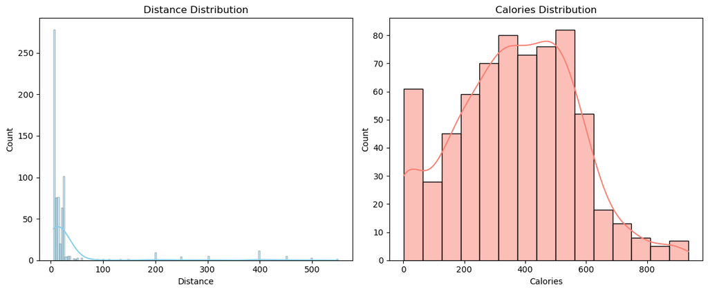

```python
fig, axes = plt.subplots(1, 2, figsize=(12, 5))

sns.histplot(data=df, x="Distance", ax=axes[0], color="skyblue", kde=True)
axes[0].set_title("Distance Distribution")

sns.histplot(data=df, x="Calories", ax=axes[1], color="salmon", kde=True)
axes[1].set_title("Calories Distribution")

plt.tight_layout()
plt.show()
```

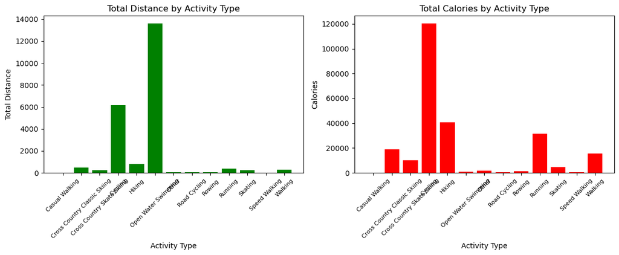

```python
fig, axes = plt.subplots(1, 2, figsize=(12, 5))
g = df.groupby("Activity Type")
activity_totals = g["Distance"].sum()
categories_totals = g["Calories"].sum()

axes[0].bar(x=activity_totals.index, height=activity_totals.values, color="green")
axes[0].set_xlabel("Activity Type")
axes[0].set_ylabel("Total Distance")
axes[0].set_title("Total Distance by Activity Type")
axes[0].tick_params(axis="x", labelsize=8, rotation=45)

axes[1].bar(x=categories_totals.index, height=categories_totals.values, color="red")
axes[1].set_xlabel("Activity Type")
axes[1].set_ylabel("Calories")
axes[1].set_title("Total Calories by Activity Type")
axes[1].tick_params(axis="x", labelsize=8, rotation=45)


plt.tight_layout()
plt.show()
```

[figure not shown]

```python
# Grouped by a categorical column
axes = df.boxplot(column=["Distance", "Calories"], by="Activity Type", figsize=(12, 6))
plt.title("Distance by Activity Type")
plt.suptitle("")
plt.xlabel("Activity Type")
plt.ylabel("Distance")
plt.xticks(rotation=45)
for ax in axes.flatten():
    ax.tick_params(axis="x", labelsize=8, labelrotation=45)

plt.tight_layout()
plt.show()
```

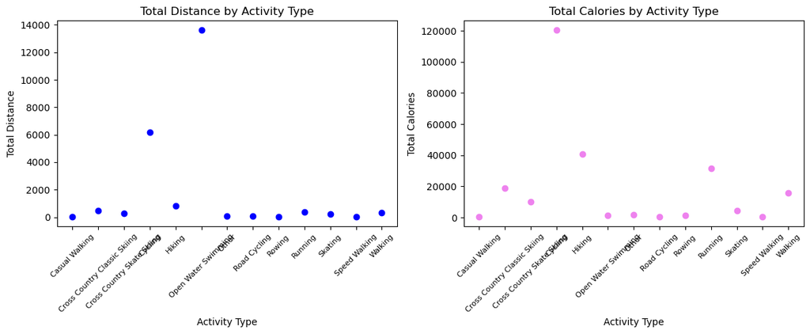

```python
fig, axes = plt.subplots(1, 2, figsize=(12, 5))
g = df.groupby("Activity Type")
activity_totals = g["Distance"].sum()
categories_totals = g["Calories"].sum()

axes[0].scatter(x=activity_totals.index, y=activity_totals.values, color="blue")
axes[0].set_xlabel("Activity Type")
axes[0].set_ylabel("Total Distance")
axes[0].set_title("Total Distance by Activity Type")
axes[0].tick_params(axis="x", labelsize=8, rotation=45)

axes[1].scatter(x=categories_totals.index, y=categories_totals.values, color="violet")
axes[1].set_xlabel("Activity Type")
axes[1].set_ylabel("Total Calories")
axes[1].set_title("Total Calories by Activity Type")
axes[1].tick_params(axis="x", labelsize=8, rotation=45)

plt.tight_layout()
plt.show()
```

## Task: AI statement (mandatory, missing AI statement (if AI used) is considered fraud)

### What I've used Gemini for:

- **Drafting general ideas**, such as "how to check that data looks okay in general."
- **Correcting code syntax and English grammar errors.**
- **Adding custom settings** to chart visualizations.
- **Using VS Code's Auto-complete feature** to finish function names (e.g., typing `df.des...` and pressing Tab to autocomplete `df.describe()`).

### What I haven't used AI for:

- **Completing an entire task from start to finish**, as doing so prevents me from learning and retaining new concepts.

## Task: Self assessment (mandatory, missing self assessment causes -1 point)

I've completed all the tasks and followed the instruction. All the expected outcomes have been fullfilled, only some of them might depend on the specific contexts, such as cleaning unuseful data and visualization, but the mandaroty requirements have been fullfilled.

So, I mark my own assessment is 10 points.

## Homework return (mandatory)

- File > Save and Export Notebook As > HTML
- Then take a look the produced HTML that it looks ok and readable (= it looks like this Jupyter notebook looks, so no html source code etc. shall be visible)
- Return to Itslearning, only the html document is returned, *not the .ipynb